# **Deep Learning Capstone Project: Facial Emotion Recognition**

## **Context**

Deep Learning has found applications in many predictive tasks relating to more unstructured forms of data over the last few years, such as images, text, audio and video. Many of these tasks seem to be in the vein of a larger direction of predictive modeling that aims to match human-level performance on such tasks, because humans have evolved to specialize in performing intelligent actions on such unstructured data. As a specific branch of AI (also called Affective Computing or Emotion AI) Artificial Emotional Intelligence stands for the study and development of technologies and computers that can read human emotions by means of analyzing body gestures, facial expressions, voice tone, etc. and react appropriately to them.

In the field of human-machine interaction, facial expression recognition is critical. From recent research, it has been found that as much as 55% of communication of sentiment takes place through facial expressions and other visual cues. Therefore, training a model to identify facial emotions accurately is an important step towards the development of emotionally intelligent behavior in machines with AI capabilities. Automatic facial expression recognition systems could have many applications, including but not limited to any use case that requires human behavior understanding, detection of mental disorders, and creating a higher quality of virtual assistant for customer-facing businesses.

## **Objective**

The goal of this project is to use Deep Learning and Artificial Intelligence techniques to create a computer vision model that can accurately detect facial emotions. The model should be able to perform multi-class classification on images of facial expressions, to classify the expressions according to the associated emotion.

## **About the dataset**

The data set consists of 3 folders, i.e., **'test'**, **'train'**, and **'validation'**.

Each of these folders has four subfolders:

- **‘happy’**: Images of people who have happy facial expressions.
- **‘sad’**: Images of people with sad or upset facial expressions.
- **‘surprise’**: Images of people who have shocked or surprised facial expressions.
- **‘neutral’**: Images of people showing no prominent emotion in their facial expression at all.

## **Mount the drive**

Let us start by mounting the Google drive. You can run the below cell to mount the Google drive.

```python
from google.colab import drive
drive.mount('/content/drive')
```

## **Importing the necessary libraries**

```python
import numpy as np
import pandas as pd
import matplotlib.pyplot as plt
import os
import zipfile
import random
from PIL import Image
from typing import List
from datetime import datetime

# For Data Visualization
import cv2
import seaborn as sns

# For Model Building
import tensorflow as tf
import keras
from tensorflow.keras.models import Sequential, Model # Sequential API for sequential model
from tensorflow.keras.layers import Dense, Dropout, Flatten # Importing different layers
from tensorflow.keras.layers import Conv2D, MaxPooling2D, BatchNormalization, Activation, Input, LeakyReLU, Activation
from tensorflow.keras import backend
from tensorflow.keras.utils import to_categorical # To perform one-hot encoding
from tensorflow.keras.optimizers import RMSprop, Adam, SGD # Optimizers for optimizing the model
from tensorflow.keras.callbacks import EarlyStopping  # Regularization method to prevent the overfitting
from tensorflow.keras.callbacks import ModelCheckpoint
from tensorflow.keras import losses, optimizers
from tensorflow.keras.preprocessing.image import load_img
from sklearn.metrics import classification_report
from sklearn.metrics import confusion_matrix
```

**Let us check the version of tensorflow.**

```python
print(tf.__version__)
```

```
2.15.0
```

## **Load the dataset**

```python
# Storing the path of the data file from the Google drive
path = '/content/drive/MyDrive/Studies/MIT-AI-ML/11. Capstone Project/Facial_emotion_images.zip'

# The data is provided as a zip file so we need to extract the files from the zip file
with zipfile.ZipFile(path, 'r') as zip_ref:
    zip_ref.extractall()
```

## **Preparing the Data**

The dataset has three folders, i.e., 'train', 'validation' and 'test'. Each of these folders has four sub-folders, namely 'happy', 'neutral', 'sad', and 'surprise'. We will have the train and test path stored in a variable named 'SUBDIRS', and a base directory 'DATADIR'. The names of the sub-folders, which will be the classes for our classification task will be stored in an array called 'CATEGORIES'.

```python
DATADIR = "/content/Facial_emotion_images"  # Base directory
SUBDIRS = ["train", "validation", "test"]  # Subdirectories
CATEGORIES = ["happy", "neutral", "sad", "surprise"]  # Emotion categories
```

We are going to check the size of one image, and then check if all the other images have the same size. In case, they are different, we'll resize the ones that are different.

```python
def get_first_image_size(directory, sub_dirs, categories):
    """
    Returns the size of the first image found in the specified directories.

    Parameters:
    - directory (str): The base directory of the dataset.
    - sub_dirs (list of str): Subdirectories to search through (e.g., ['train', 'validation', 'test']).
    - categories (list of str): Categories (e.g., ['happy', 'neutral', 'sad', 'surprise']).

    Returns:
    - tuple: Size of the first image found (width, height).
    """
    for sub_dir in sub_dirs:
        for category in categories:
            path = os.path.join(directory, sub_dir, category)
            for img_name in os.listdir(path):
                img_path = os.path.join(path, img_name)
                with Image.open(img_path) as img:
                    return img.size  # Return the size of the first image found
```

```python
# Get the size of the first image
expected_size = get_first_image_size(DATADIR, SUBDIRS, CATEGORIES)

print(f"Expected size of the first image: {expected_size}")
```

```
Expected size of the first image: (48, 48)
```

```python
def check_image_sizes(directory, sub_dirs, categories, target_size):
    """
    Checks if all images in the specified directories match the target size.

    Parameters:
    - directory (str): The base directory of the dataset.
    - sub_dirs (list of str): Subdirectories to search through.
    - categories (list of str): Categories to search through.
    - target_size (tuple): The expected size of the images (width, height).

    Returns:
    - bool: True if all images match the target size, False otherwise.
    """
    all_match = True  # Flag to keep track of size match

    for sub_dir in sub_dirs:
        for category in categories:
            path = os.path.join(directory, sub_dir, category)
            for img_name in os.listdir(path):
                img_path = os.path.join(path, img_name)
                with Image.open(img_path) as img:
                    if img.size != target_size:
                        print(f"Image {img_path} has a different size: {img.size}, expected: {target_size}")
                        all_match = False
                        return all_match  # Return early upon first mismatch
    return all_match
```

```python
# Check if all images match the expected size
all_match = check_image_sizes(DATADIR, SUBDIRS, CATEGORIES, expected_size)
if all_match:
    print("All images match the expected size.")
else:
    print("Not all images match the expected size.")
```

```
All images match the expected size.
```

## **Visualizing images randomly from each class**

```python
def visualize_emotion_images(directory: str, sub_dirs: List[str], emotion: str, image_count: int = 9) -> None:
    """
    Visualizes a specified number of images from a given emotion class directory across specified subdirectories.

    Parameters:
    - directory (str): The base directory where emotion class folders are located across subdirectories.
    - sub_dirs (List[str]): List of subdirectories ('train', 'validation', 'test') to search through.
    - emotion (str): The specific emotion class to visualize images from.
    - image_count (int): The number of images to display. Defaults to 9.

    Returns:
    - None: This function does not return any value but displays images inline.
    """
    image_paths: List[str] = []  # To store paths of images to be displayed

    # Iterate through the specified subdirectories to collect image paths
    for sub_dir in sub_dirs:
        emotion_dir: str = os.path.join(directory, sub_dir, emotion)
        if os.path.isdir(emotion_dir):
            for img_name in os.listdir(emotion_dir):
                img_path = os.path.join(emotion_dir, img_name)
                image_paths.append(img_path)

    # If there are no images found for the emotion, print a message and return
    if not image_paths:
        print(f"No images found for the specified emotion: {emotion}")
        return

    # Select a random subset of image paths
    selected_image_paths: np.ndarray = np.random.choice(image_paths, min(image_count, len(image_paths)), replace=False)

    # Setup for plotting
    fig = plt.figure(figsize=(4, 4))
    columns: int = 3
    rows: int = image_count // columns + (1 if image_count % columns else 0)

    # Iterate over the selected images and display them
    for i, image_path in enumerate(selected_image_paths, start=1):
        ax = fig.add_subplot(rows, columns, i)
        image = load_img(image_path, target_size=(48, 48))  # Ensure the image is resized to 48x48
        plt.imshow(image)
        plt.axis('off')

    plt.tight_layout()
    plt.show()
```

### **Happy**

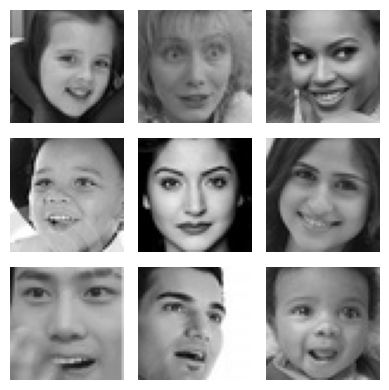

```python
visualize_emotion_images(DATADIR, SUBDIRS, "happy", 9)
```

**Observations:**

- The images appear to be in grayscale and vary in terms of lighting, contrast, and clarity.
- The images display a range of happy expressions, from broad smiles showing teeth to subtle smiles without teeth. Also a diversity of subjects in terms of age, gender and also ethnicity.

### **Sad**

[figure not shown]

```python
visualize_emotion_images(DATADIR, SUBDIRS, "sad", 9)
```

**Observations:**

- The images capture a wide spectrum of sadness, from subtle, somber expressions to more overt manifestations like crying.
- The dataset includes faces with different orientations and features. Some faces are directly looking at the camera, while others are tilted or partially turned away.

### **Surprise**

[figure not shown]

```python
visualize_emotion_images(DATADIR, SUBDIRS, "surprise", 9)
```

**Observations:**

- The images showcase a range of intensities of surprise, from wide-eyed and open-mouthed expressions to more subdued, raised-eyebrow looks.
- The subjects vary in age, including both infants and adults.

### **Neutral**

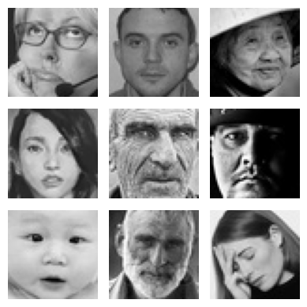

```python
visualize_emotion_images(DATADIR, SUBDIRS, "neutral", 9)
```

**Observations:**

- The defining characteristic of these images is the absence of clear, expressive features that denote a specific emotion.
- Some faces may have subtle features that could be misconstrued as expressing a mild emotion.

### **Data Preprocessing**

In the following cells, we will shuffle our training and testing_data, and store the images in X_train, and X_test, and the labels in y_train, and y_test respectively.

```python
# Function to load images and labels
def load_data(data_dir, categories):
    images = []
    labels = []
    for category in categories:
        path = os.path.join(data_dir, category)
        class_num = categories.index(category)
        for img_name in os.listdir(path):
            try:
                img_path = os.path.join(path, img_name)
                img = Image.open(img_path)
                images.append(np.array(img))
                labels.append(class_num)
            except Exception as e:
                print(f"Failed to process {img_name}: {e}")
    return images, labels
```

```python
SUBDIRS_DICT = {'train': 'train', 'test': 'test'}
```

```python
# Load training and testing data
X_train, y_train = load_data(os.path.join(DATADIR, SUBDIRS_DICT['train']), CATEGORIES)
X_test, y_test = load_data(os.path.join(DATADIR, SUBDIRS_DICT['test']), CATEGORIES)

# Convert lists to numpy arrays and add an extra dimension for grayscale channel
X_train = np.expand_dims(np.array(X_train), axis=-1)
X_test = np.expand_dims(np.array(X_test), axis=-1)
y_train = np.array(y_train)
y_test = np.array(y_test)

# Shuffle the training data
indices = np.arange(X_train.shape[0])
np.random.shuffle(indices)
X_train = X_train[indices]
y_train = y_train[indices]

# Shuffle the testing data
indices = np.arange(X_test.shape[0])
np.random.shuffle(indices)
X_test = X_test[indices]
y_test = y_test[indices]

# Check the shape of the data
print(f"X_train shape: {X_train.shape}")
print(f"y_train shape: {y_train.shape}")
print(f"X_test shape: {X_test.shape}")
print(f"y_test shape: {y_test.shape}")
```

```
X_train shape: (15109, 48, 48, 1)
y_train shape: (15109,)
X_test shape: (128, 48, 48, 1)
y_test shape: (128,)
```

## **Checking Distribution of Classes**

```python
# Create a mapping from indices to emotion classes
index_to_emotion = {i: emotion for i, emotion in enumerate(CATEGORIES)}

# Convert the y_train and y_test lists to DataFrames
y_train_df = pd.DataFrame(y_train, columns=["Label"])
y_test_df = pd.DataFrame(y_test, columns=["Label"])

# Map the numerical labels to actual emotion classes
y_train_df['Label'] = y_train_df['Label'].map(index_to_emotion)
y_test_df['Label'] = y_test_df['Label'].map(index_to_emotion)

# Printing the value counts of target variable with actual emotion classes
count = y_train_df['Label'].value_counts()
print(count)

print('*'*10)

# Normalized value counts
count_normalized = y_train_df['Label'].value_counts(normalize=True)
print(count_normalized)
```

```
sad         3982
neutral     3978
happy       3976
surprise    3173
Name: Label, dtype: int64
**********
sad         0.263552
neutral     0.263287
happy       0.263154
surprise    0.210007
Name: Label, dtype: float64
```

**Observation:**

- The dataset shows a near-uniform distribution for 'sad', 'neutral', and 'happy' classes, suggesting a balanced dataset.

## **Normalizing the data**

```python
# Normalizing the image data
X_train = X_train/255.0

X_test = X_test/255.0
```

## **Encoding Target Variable**

For any ML or DL techniques, the labels must be encoded into numbers or arrays, so that we can compute the cost between the predicted and the real labels.

In our scenario, we have four classes: "Happy", "Neutral", "Sad", and "Surprise". The labels for these classes would be encoded as follows:

- [1, 0, 0, 0] --------- Happy
- [0, 1, 0, 0] --------- Neutral
- [0, 0, 1, 0] --------- Sad
- [0, 0, 0, 1] --------- Surprise

Here, each emotion class is represented as a one-hot encoded array, which is a common format for categorical encoding in ML and DL tasks.

```python
# One-hot encode the 'Label' column using pandas get_dummies
y_train_encoded = pd.get_dummies(y_train_df['Label'])
y_test_encoded = pd.get_dummies(y_test_df['Label'])
```

```python
train_index_to_check = 0
test_index_to_check = 0

# Print the original label and the one-hot encoded vector from the train set
print(f"Original train label: {y_train_df.iloc[train_index_to_check]['Label']}")
print("One-hot encoded train vector:", y_train_encoded.iloc[train_index_to_check].tolist())

# Print the original label and the one-hot encoded vector from the test set
print(f"\nOriginal test label: {y_test_df.iloc[test_index_to_check]['Label']}")
print("One-hot encoded test vector:", y_test_encoded.iloc[test_index_to_check].tolist())
```

```
Original train label: sad
One-hot encoded train vector: [0, 0, 1, 0]

Original test label: neutral
One-hot encoded test vector: [0, 1, 0, 0]
```

## **Model Building**

Now that we have done data preprocessing, let's build the first Convolutional Neural Network (CNN) model.

### **Model 1 Architecture:**

```python
backend.clear_session()

# Fixing the seed for random number generators so that we can ensure we receive the same output everytime
np.random.seed(42)
import random
random.seed(42)
tf.random.set_seed(42)
```

```python
# Intializing a sequential model
model = Sequential()

# Adding first conv layer with 64 filters and kernel size 2x2, padding 'same' provides the output size same as the input size
# The input_shape denotes input image dimension
model.add(Conv2D(64, (2, 2), activation = 'relu', padding = "same", input_shape = (48, 48, 1)))

# Adding max pooling to reduce the size of output of first conv layer
model.add(MaxPooling2D((2, 2), padding = 'same'))

# Adding second conv layer with 32 filters and kernel size 2x2, padding 'same' followed by a Maxpooling2D layer
model.add(Conv2D(32, (2, 2), activation = 'relu', padding = "same"))
model.add(MaxPooling2D((2, 2), padding = 'same'))

# Add third conv layer with 32 filters and kernel size 2x2, padding 'same' followed by a Maxpooling2D layer
model.add(Conv2D(32, (2, 2), activation='relu', padding="same"))
model.add(MaxPooling2D((2, 2), padding = 'same'))

# Flattening the output of the conv layer after max pooling to make it ready for creating dense connections
model.add(Flatten())

# Adding a fully connected dense layer with 100 neurons
model.add(Dense(100, activation = 'relu'))

# Adding the output layer with 3 neurons and activation functions as softmax since this is a multi-class classification problem
model.add(Dense(4, activation = 'softmax'))

# Using SGD Optimizer
opt = SGD(learning_rate = 0.01, momentum = 0.9)

# Compiling the model
model.compile(optimizer = opt, loss = 'categorical_crossentropy', metrics = ['accuracy'])

# Generating the summary of the model
model.summary()
```

```
Model: "sequential"
_________________________________________________________________
 Layer (type)                Output Shape              Param #
=================================================================
 conv2d (Conv2D)             (None, 48, 48, 64)        320

 max_pooling2d (MaxPooling2  (None, 24, 24, 64)        0
 D)

 conv2d_1 (Conv2D)           (None, 24, 24, 32)        8224

 max_pooling2d_1 (MaxPoolin  (None, 12, 12, 32)        0
 g2D)

 conv2d_2 (Conv2D)           (None, 12, 12, 32)        4128

 max_pooling2d_2 (MaxPoolin  (None, 6, 6, 32)          0
 g2D)

 flatten (Flatten)           (None, 1152)              0

 dense (Dense)               (None, 100)               115300

 dense_1 (Dense)             (None, 4)                 404

=================================================================
Total params: 128376 (501.47 KB)
Trainable params: 128376 (501.47 KB)
Non-trainable params: 0 (0.00 Byte)
_________________________________________________________________
```

**Observations:**

- As we can see from the above summary, this CNN model will train and learn **128,376 parameters (weights and biases).**
- There are **no non-trainable parameters** in the model.

### **Training the Model**

Let's now train the model using the training data.

```python
results_path = '/content/drive/MyDrive/Studies/MIT-AI-ML/11. Capstone Project/results'
```

```python
# Get the current time
current_time = datetime.now().strftime('%Y%m%d-%H%M%S')

# The following lines of code saves the best model's parameters if training accuracy goes down on further training
es = EarlyStopping(monitor = 'val_loss', mode = 'min', verbose = 1, patience = 5)
mc = ModelCheckpoint(f'{results_path}/best_model_{current_time}.keras',
                     monitor='val_accuracy',
                     mode='max',
                     verbose=1,
                     save_best_only=True)

# Fitting the model with 30 epochs and validation_split as 20%
history=model.fit(X_train,
          y_train_encoded,
          epochs = 30,
          batch_size= 128, validation_split = 0.20, callbacks = [es, mc])
```

```
Epoch 1: val_accuracy improved from -inf to 0.30576, saving model to /content/drive/MyDrive/Studies/MIT-AI-ML/11. Capstone Project/results/best_model_20240302-212130.keras
Epoch 2: val_accuracy improved from 0.30576 to 0.35440, saving model to /content/drive/MyDrive/Studies/MIT-AI-ML/11. Capstone Project/results/best_model_20240302-212130.keras
Epoch 3: val_accuracy improved from 0.35440 to 0.37062, saving model to /content/drive/MyDrive/Studies/MIT-AI-ML/11. Capstone Project/results/best_model_20240302-212130.keras
Epoch 4: val_accuracy improved from 0.37062 to 0.44242, saving model to /content/drive/MyDrive/Studies/MIT-AI-ML/11. Capstone Project/results/best_model_20240302-212130.keras
Epoch 5: val_accuracy did not improve from 0.44242
Epoch 6: val_accuracy improved from 0.44242 to 0.48511, saving model to /content/drive/MyDrive/Studies/MIT-AI-ML/11. Capstone Project/results/best_model_20240302-212130.keras
Epoch 7: val_accuracy did not improve from 0.48511
Epoch 8: val_accuracy improved from 0.48511 to 0.51489, saving model to /content/drive/MyDrive/Studies/MIT-AI-ML/11. Capstone Project/results/best_model_20240302-212130.keras
Epoch 9: val_accuracy improved from 0.51489 to 0.51522, saving model to /content/drive/MyDrive/Studies/MIT-AI-ML/11. Capstone Project/results/best_model_20240302-212130.keras
Epoch 10: val_accuracy improved from 0.51522 to 0.53839, saving model to /content/drive/MyDrive/Studies/MIT-AI-ML/11. Capstone Project/results/best_model_20240302-212130.keras
Epoch 11: val_accuracy improved from 0.53839 to 0.54368, saving model to /content/drive/MyDrive/Studies/MIT-AI-ML/11. Capstone Project/results/best_model_20240302-212130.keras
Epoch 12: val_accuracy improved from 0.54368 to 0.55989, saving model to /content/drive/MyDrive/Studies/MIT-AI-ML/11. Capstone Project/results/best_model_20240302-212130.keras
Epoch 13: val_accuracy did not improve from 0.55989
Epoch 14: val_accuracy improved from 0.55989 to 0.56784, saving model to /content/drive/MyDrive/Studies/MIT-AI-ML/11. Capstone Project/results/best_model_20240302-212130.keras
Epoch 15: val_accuracy did not improve from 0.56784
Epoch 16: val_accuracy improved from 0.56784 to 0.58372, saving model to /content/drive/MyDrive/Studies/MIT-AI-ML/11. Capstone Project/results/best_model_20240302-212130.keras
Epoch 17: val_accuracy improved from 0.58372 to 0.59166, saving model to /content/drive/MyDrive/Studies/MIT-AI-ML/11. Capstone Project/results/best_model_20240302-212130.keras
Epoch 18: val_accuracy did not improve from 0.59166
Epoch 19: val_accuracy did not improve from 0.59166
Epoch 20: val_accuracy did not improve from 0.59166
Epoch 21: val_accuracy improved from 0.59166 to 0.59927, saving model to /content/drive/MyDrive/Studies/MIT-AI-ML/11. Capstone Project/results/best_model_20240302-212130.keras
Epoch 22: val_accuracy improved from 0.59927 to 0.60258, saving model to /content/drive/MyDrive/Studies/MIT-AI-ML/11. Capstone Project/results/best_model_20240302-212130.keras
Epoch 22: early stopping
```

### **Plotting the Training and Validation Accuracies**

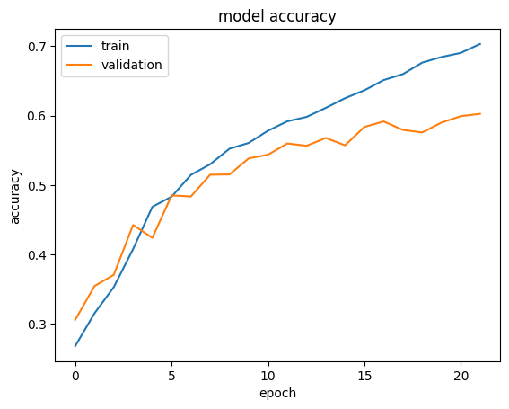

```python
# Plotting the training and validation accuracies for each epoch

plt.plot(history.history['accuracy'])
plt.plot(history.history['val_accuracy'])
plt.title('model accuracy')
plt.ylabel('accuracy')
plt.xlabel('epoch')
plt.legend(['train', 'validation'], loc='upper left')
plt.show()
```

### **Checking Test Accuracy**

```python
model.evaluate(X_test, (y_test_encoded))
```

```
[0.8616584539413452, 0.625]
```

**Observations:**

### **Plotting Confusion Matrix**

```
              precision    recall  f1-score   support

       happy       0.61      0.62      0.62        32
     neutral       0.73      0.50      0.59        32
         sad       0.47      0.56      0.51        32
    surprise       0.74      0.81      0.78        32

    accuracy                           0.62       128
   macro avg       0.64      0.62      0.62       128
weighted avg       0.64      0.62      0.62       128
```

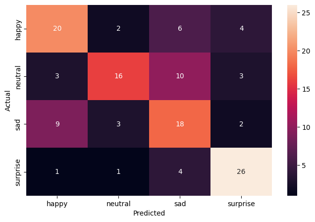

```python
pred = model.predict(X_test)
pred = np.argmax(pred, axis=1)

# Convert the pandas DataFrame to a numpy array if it's not already
if isinstance(y_test_encoded, pd.DataFrame):
    y_test_encoded = y_test_encoded.values

# Now we can safely use np.argmax
y_true = np.argmax(y_test_encoded, axis=1)

# Printing the classification report with actual emotion labels
print(classification_report(y_true, pred, target_names=CATEGORIES))

# Plotting the heatmap using confusion matrix
cm = confusion_matrix(y_true, pred)
plt.figure(figsize=(8, 5))
sns.heatmap(cm, annot=True, fmt='.0f', xticklabels=CATEGORIES, yticklabels=CATEGORIES)
plt.ylabel('Actual')
plt.xlabel('Predicted')
plt.show()
```

**Observations:**

### **Model 2 Architecture:**

```python
backend.clear_session()

# Fixing the seed for random number generators so that we can ensure we receive the same output everytime
np.random.seed(42)
import random
random.seed(42)
tf.random.set_seed(42)
```

```python
# Initializing a sequential model
model_2 = Sequential()

# Adding first conv layer with 256 filters and kernel size 4x4, with ReLU activation and padding 'same' provides the output size same as the input size
# The input_shape denotes input image dimension
model_2.add(Conv2D(filters = 256, kernel_size = (4, 4), padding = 'Same', activation = 'relu', input_shape = (48, 48, 1)))

# Adding max pooling to reduce the size of output of first conv layer
model_2.add(MaxPooling2D(pool_size = (2, 2), strides = (2, 2)))

#  Adding dropout to randomly switch off 25% neurons to reduce overfitting
model_2.add(Dropout(0.25))

# Adding second conv layer with 128 filters and with kernel size 4x4 and ReLu activation function
model_2.add(Conv2D(filters = 128, kernel_size = (4, 4), padding = 'Same', activation = 'relu'))

# Adding max pooling to reduce the size of output of first conv layer
model_2.add(MaxPooling2D(pool_size = (2, 2), strides = (2, 2)))

#  Adding dropout to randomly switch off 25% neurons to reduce overfitting
model_2.add(Dropout(0.25))

# Adding third conv layer with 64 filters and with kernel size 2x2 and ReLu activation function
model_2.add(Conv2D(filters = 64, kernel_size = (2, 2), padding = 'Same', activation = 'relu'))

# Adding max pooling to reduce the size of output of first conv layer
model_2.add(MaxPooling2D(pool_size = (2, 2), strides = (2, 2)))

#  Adding dropout to randomly switch off 25% neurons to reduce overfitting
model_2.add(Dropout(0.25))

# Adding fourth conv layer with 32 filters and with kernel size 2x2 and ReLu activation function
model_2.add(Conv2D(filters = 32, kernel_size = (2, 2), padding = 'Same', activation = 'relu'))

# Adding max pooling to reduce the size of output of first conv layer
model_2.add(MaxPooling2D(pool_size = (2, 2), strides = (2, 2)))

#  Adding dropout to randomly switch off 25% neurons to reduce overfitting
model_2.add(Dropout(0.25))

# Flattening the 3-d output of the conv layer after max pooling to make it ready for creating dense connections
model_2.add(Flatten())

# Adding first fully connected dense layer with 64 neurons
model_2.add(Dense(64, activation = "relu"))

# Adding second fully connected dense layer with 32 neurons
model_2.add(Dense(32, activation = "relu"))

# Adding the output layer with 4 neurons and activation functions as softmax since this is a multi-class classification problem
model_2.add(Dense(4, activation = "softmax"))

# Using Adam Optimizer
optimizer = Adam(learning_rate = 0.001)

# Compile the model
model_2.compile(optimizer = optimizer , loss = "categorical_crossentropy", metrics = ["accuracy"])

model_2.summary()
```

```
Model: "sequential"
_________________________________________________________________
 Layer (type)                Output Shape              Param #
=================================================================
 conv2d (Conv2D)             (None, 48, 48, 256)       4352

 max_pooling2d (MaxPooling2  (None, 24, 24, 256)       0
 D)

 dropout (Dropout)           (None, 24, 24, 256)       0

 conv2d_1 (Conv2D)           (None, 24, 24, 128)       524416

 max_pooling2d_1 (MaxPoolin  (None, 12, 12, 128)       0
 g2D)

 dropout_1 (Dropout)         (None, 12, 12, 128)       0

 conv2d_2 (Conv2D)           (None, 12, 12, 64)        32832

 max_pooling2d_2 (MaxPoolin  (None, 6, 6, 64)          0
 g2D)

 dropout_2 (Dropout)         (None, 6, 6, 64)          0

 conv2d_3 (Conv2D)           (None, 6, 6, 32)          8224

 max_pooling2d_3 (MaxPoolin  (None, 3, 3, 32)          0
 g2D)

 dropout_3 (Dropout)         (None, 3, 3, 32)          0

 flatten (Flatten)           (None, 288)               0

 dense (Dense)               (None, 64)                18496

 dense_1 (Dense)             (None, 32)                2080

 dense_2 (Dense)             (None, 4)                 132

=================================================================
Total params: 590532 (2.25 MB)
Trainable params: 590532 (2.25 MB)
Non-trainable params: 0 (0.00 Byte)
_________________________________________________________________
```

**Observations:**

- The model is relatively deep, with multiple convolutional layers followed by max pooling layers, indicating it is designed to capture complex features from the input images.
- A significant number of parameters are concentrated in the earlier convolutional layers, especially the second Conv2D layer (524,416 parameters), which suggests that the model may be learning a variety of low to mid-level features in the initial stages.

### **Training the Model**

Let's now train the model using the training data.

```python
# Get the current time
current_time = datetime.now().strftime('%Y%m%d-%H%M%S')

# The following lines of code saves the best model's parameters if training accuracy goes down on further training
es = EarlyStopping(monitor = 'val_loss', mode = 'min', verbose = 1, patience = 5)
mc = ModelCheckpoint(f'{results_path}/best_model_2_{current_time}.keras',
                     monitor='val_accuracy',
                     mode='max',
                     verbose=1,
                     save_best_only=True)

# Fitting the model_2 with 60 epochs and validation_split as 20%
history_2=model_2.fit(X_train,
          y_train_encoded,
          epochs = 60,
          batch_size= 64, validation_split = 0.20, callbacks = [es, mc])
```

```
Epoch 1: val_accuracy improved from -inf to 0.34083, saving model to /content/drive/MyDrive/Studies/MIT-AI-ML/11. Capstone Project/results/best_model_2_20240302-212805.keras
Epoch 2: val_accuracy improved from 0.34083 to 0.42091, saving model to /content/drive/MyDrive/Studies/MIT-AI-ML/11. Capstone Project/results/best_model_2_20240302-212805.keras
Epoch 3: val_accuracy improved from 0.42091 to 0.45235, saving model to /content/drive/MyDrive/Studies/MIT-AI-ML/11. Capstone Project/results/best_model_2_20240302-212805.keras
Epoch 4: val_accuracy improved from 0.45235 to 0.49570, saving model to /content/drive/MyDrive/Studies/MIT-AI-ML/11. Capstone Project/results/best_model_2_20240302-212805.keras
Epoch 5: val_accuracy improved from 0.49570 to 0.54765, saving model to /content/drive/MyDrive/Studies/MIT-AI-ML/11. Capstone Project/results/best_model_2_20240302-212805.keras
Epoch 6: val_accuracy improved from 0.54765 to 0.59232, saving model to /content/drive/MyDrive/Studies/MIT-AI-ML/11. Capstone Project/results/best_model_2_20240302-212805.keras
Epoch 7: val_accuracy improved from 0.59232 to 0.60026, saving model to /content/drive/MyDrive/Studies/MIT-AI-ML/11. Capstone Project/results/best_model_2_20240302-212805.keras
Epoch 8: val_accuracy improved from 0.60026 to 0.61383, saving model to /content/drive/MyDrive/Studies/MIT-AI-ML/11. Capstone Project/results/best_model_2_20240302-212805.keras
Epoch 9: val_accuracy did not improve from 0.61383
Epoch 10: val_accuracy improved from 0.61383 to 0.62707, saving model to /content/drive/MyDrive/Studies/MIT-AI-ML/11. Capstone Project/results/best_model_2_20240302-212805.keras
Epoch 11: val_accuracy improved from 0.62707 to 0.64328, saving model to /content/drive/MyDrive/Studies/MIT-AI-ML/11. Capstone Project/results/best_model_2_20240302-212805.keras
Epoch 12: val_accuracy improved from 0.64328 to 0.64692, saving model to /content/drive/MyDrive/Studies/MIT-AI-ML/11. Capstone Project/results/best_model_2_20240302-212805.keras
Epoch 13: val_accuracy did not improve from 0.64692
Epoch 14: val_accuracy improved from 0.64692 to 0.64990, saving model to /content/drive/MyDrive/Studies/MIT-AI-ML/11. Capstone Project/results/best_model_2_20240302-212805.keras
Epoch 15: val_accuracy improved from 0.64990 to 0.65520, saving model to /content/drive/MyDrive/Studies/MIT-AI-ML/11. Capstone Project/results/best_model_2_20240302-212805.keras
Epoch 16: val_accuracy did not improve from 0.65520
Epoch 17: val_accuracy improved from 0.65520 to 0.67042, saving model to /content/drive/MyDrive/Studies/MIT-AI-ML/11. Capstone Project/results/best_model_2_20240302-212805.keras
Epoch 18: val_accuracy did not improve from 0.67042
Epoch 19: val_accuracy did not improve from 0.67042
Epoch 20: val_accuracy improved from 0.67042 to 0.68365, saving model to /content/drive/MyDrive/Studies/MIT-AI-ML/11. Capstone Project/results/best_model_2_20240302-212805.keras
Epoch 21: val_accuracy did not improve from 0.68365
Epoch 22: val_accuracy did not improve from 0.68365
Epoch 23: val_accuracy did not improve from 0.68365
Epoch 24: val_accuracy improved from 0.68365 to 0.68465, saving model to /content/drive/MyDrive/Studies/MIT-AI-ML/11. Capstone Project/results/best_model_2_20240302-212805.keras
Epoch 25: val_accuracy did not improve from 0.68465
Epoch 26: val_accuracy did not improve from 0.68465
Epoch 27: val_accuracy improved from 0.68465 to 0.69027, saving model to /content/drive/MyDrive/Studies/MIT-AI-ML/11. Capstone Project/results/best_model_2_20240302-212805.keras
Epoch 28: val_accuracy improved from 0.69027 to 0.69325, saving model to /content/drive/MyDrive/Studies/MIT-AI-ML/11. Capstone Project/results/best_model_2_20240302-212805.keras
Epoch 29: val_accuracy improved from 0.69325 to 0.69523, saving model to /content/drive/MyDrive/Studies/MIT-AI-ML/11. Capstone Project/results/best_model_2_20240302-212805.keras
Epoch 30: val_accuracy improved from 0.69523 to 0.69557, saving model to /content/drive/MyDrive/Studies/MIT-AI-ML/11. Capstone Project/results/best_model_2_20240302-212805.keras
Epoch 31: val_accuracy did not improve from 0.69557
Epoch 32: val_accuracy did not improve from 0.69557
Epoch 33: val_accuracy did not improve from 0.69557
Epoch 34: val_accuracy improved from 0.69557 to 0.69921, saving model to /content/drive/MyDrive/Studies/MIT-AI-ML/11. Capstone Project/results/best_model_2_20240302-212805.keras
Epoch 35: val_accuracy improved from 0.69921 to 0.70218, saving model to /content/drive/MyDrive/Studies/MIT-AI-ML/11. Capstone Project/results/best_model_2_20240302-212805.keras
Epoch 36: val_accuracy did not improve from 0.70218
Epoch 37: val_accuracy improved from 0.70218 to 0.70251, saving model to /content/drive/MyDrive/Studies/MIT-AI-ML/11. Capstone Project/results/best_model_2_20240302-212805.keras
Epoch 38: val_accuracy improved from 0.70251 to 0.71277, saving model to /content/drive/MyDrive/Studies/MIT-AI-ML/11. Capstone Project/results/best_model_2_20240302-212805.keras
Epoch 39: val_accuracy did not improve from 0.71277
Epoch 40: val_accuracy did not improve from 0.71277
Epoch 41: val_accuracy did not improve from 0.71277
Epoch 42: val_accuracy did not improve from 0.71277
Epoch 43: val_accuracy did not improve from 0.71277
Epoch 43: early stopping
```

### **Plotting the Training and Validation Accuracies**

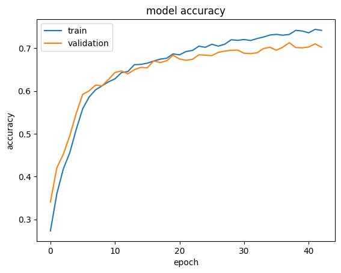

```python
plt.plot(history_2.history['accuracy'])
plt.plot(history_2.history['val_accuracy'])
plt.title('model accuracy')
plt.ylabel('accuracy')
plt.xlabel('epoch')
plt.legend(['train', 'validation'], loc = 'upper left')
plt.show()
```

### **Checking Test Accuracy**

```python
model_2.evaluate(X_test, y_test_encoded)
```

```
[0.6444226503372192, 0.734375]
```

**Observations:**

### **Plotting Confusion Matrix**

```
              precision    recall  f1-score   support

       happy       0.87      0.81      0.84        32
     neutral       0.68      0.59      0.63        32
         sad       0.57      0.66      0.61        32
    surprise       0.85      0.88      0.86        32

    accuracy                           0.73       128
   macro avg       0.74      0.73      0.74       128
weighted avg       0.74      0.73      0.74       128
```

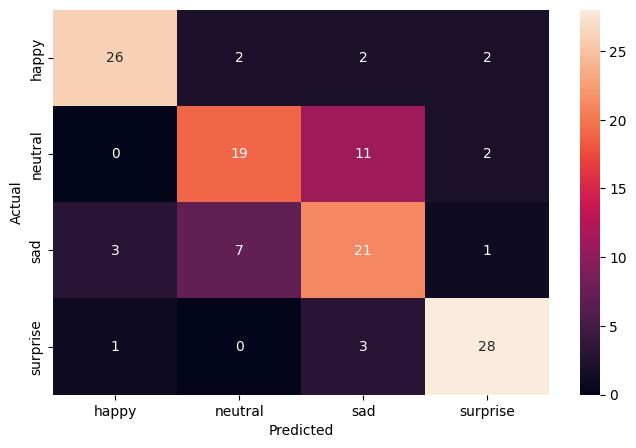

```python
pred = model_2.predict(X_test)
pred = np.argmax(pred, axis=1)

# Convert the pandas DataFrame to a numpy array if it's not already
if isinstance(y_test_encoded, pd.DataFrame):
    y_test_encoded = y_test_encoded.values

# Now we can safely use np.argmax
y_true = np.argmax(y_test_encoded, axis=1)

# Printing the classification report with actual emotion labels
print(classification_report(y_true, pred, target_names=CATEGORIES))

# Plotting the heatmap using confusion matrix
cm = confusion_matrix(y_true, pred)
plt.figure(figsize=(8, 5))
sns.heatmap(cm, annot=True, fmt='.0f', xticklabels=CATEGORIES, yticklabels=CATEGORIES)
plt.ylabel('Actual')
plt.xlabel('Predicted')
plt.show()
```

**Observations:**

- The model shows an improved recall for the 'surprise' class, indicating better sensitivity in identifying this emotion compared to the first model.
- Both models struggle with the 'sad' class; however, the second model has shown a slight improvement in correctly predicting 'sad' emotions but still has room for improvement.
- The second model shows a higher overall accuracy, 73%, and a better balance between precision and recall, indicating improved generalization and performance across all classes.

### **Prediction**

Let us predict using the best model, i.e., model 2, by plotting four random images from X_test data and see if our best model is predicting the image correctly or not.

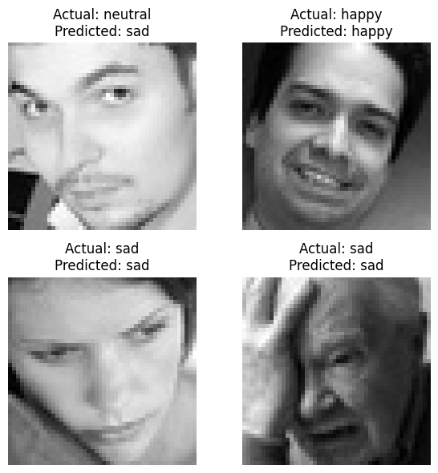

```python
# Set the number of images to display
num_images = 4

# Create a figure with subplots in a 2x2 grid
fig, axes = plt.subplots(nrows=2, ncols=2, figsize=(6, 6))

# Flatten the axes array for easy iteration
axes = axes.flatten()

for i in range(num_images):
    # Pick a random image from X_test
    random_index = random.randint(0, len(X_test) - 1)
    test_image = X_test[random_index]

    # Predict the emotion of the image using model_2
    predicted_probabilities = model_2.predict(np.expand_dims(test_image, axis=0))
    predicted_label_index = np.argmax(predicted_probabilities)
    predicted_label = CATEGORIES[predicted_label_index]

    # Retrieve the actual label for the image
    actual_label_index = np.argmax(y_test_encoded.values[random_index]) if isinstance(y_test_encoded, pd.DataFrame) else np.argmax(y_test_encoded[random_index])
    actual_label = CATEGORIES[actual_label_index]

    # Plot the image in the corresponding subplot
    ax = axes[i]
    ax.imshow(test_image.squeeze(), cmap='gray')  # Assuming X_test is 4D with the last dimension being 1 for grayscale
    ax.set_title(f"Actual: {actual_label}\nPredicted: {predicted_label}")
    ax.axis('off')  # Hide the axis

plt.tight_layout()
plt.show()
```

**Observation:**

## **Conclusion and Recommendations**

- The second iteration of the CNN model demonstrated better performance compared to the initial model, with improved accuracy and better balance across precision and recall for the different emotion classes, around 73%.
- The models, particularly the second one, showed varying degrees of success with different emotions, with 'surprise' being predicted most accurately and 'neutral' and 'sad' being the most challenging for the model to predict correctly.
- The introduction of dropout layers helped mitigate overfitting, as evidenced by the closer convergence of training and validation accuracies in the second model.
- Recommendations for Further Work:
  - Implement data augmentation techniques to increase the diversity of the training data, which could help improve the model's ability to generalize, especially for underperforming classes like 'sad' or 'neutral'.
  - Further hyperparameter optimization, including learning rate adjustments, batch size variations, and exploring different model architectures, could lead to improvements in model performance.